# Case Study Bike Share

Rakeem

2023-08-03

Note: This is a Case Study for Coursera Data Analytics course any feedback would be appreciated on this publication, thanks.

rocky.sensei@gmail.com

# Coursera Data Analytics Course: Case Study 1 - Cyclistic Ride Share

Setting the enviornment loading ‘tidyverse’ and ‘ggplot2’ packages.

```r
library(tidyverse)
```

```r
library(ggplot2)
```

# Step 1 - Ask

### Exlporing Data

I am looking at a year of data in ‘2021’ collected by Cyclistic a ride share bike company out of Chicago. Through this analysis I endevor to find insights and trends on how the casual riders use Cyclistic differently than annual members. With the insights I draw from this analysis, I can help the marketing team develop stratgies on how to transform casual riders into annual members.

**The Business Task** - How do annual members and casual riders use Cyclistic bikes differently?

**Who are the stakeholders?**

- Company: Cyclistic - 5,824 bicycles and 692 docking stations
- Lily Moreno - The director of marketing and my manager.
- Cyclistic marketing analytics team - my teammates.
- Cyclistic executive team.

I am dealing with large datasets. The firts dataset I name rsjan (rideshare January), and the rest are named by month. Here are the dimesions of one of the datasets and they are all around this size.

What metrics will you use to measure your data and solve the business problem?

```r
rsjan <- read_csv("Desktop/case_study_cyclistic/202101-divvy-tripdata.csv")
rsfeb <- read_csv("Desktop/case_study_cyclistic/202102-divvy-tripdata.csv")
rsmar <- read_csv("Desktop/case_study_cyclistic/202103-divvy-tripdata.csv")
rsapr <- read_csv("Desktop/case_study_cyclistic/202104-divvy-tripdata.csv")
rsmay <- read_csv("Desktop/case_study_cyclistic/202105-divvy-tripdata.csv")
rsjun <- read_csv("Desktop/case_study_cyclistic/202106-divvy-tripdata.csv")
rsjul <- read_csv("Desktop/case_study_cyclistic/202107-divvy-tripdata.csv")
rsaug <- read_csv("Desktop/case_study_cyclistic/202108-divvy-tripdata.csv")
rssep <- read_csv("Desktop/case_study_cyclistic/202109-divvy-tripdata.csv")
rsoct <- read_csv("Desktop/case_study_cyclistic/202110-divvy-tripdata.csv")
rsnov <- read_csv("Desktop/case_study_cyclistic/202111-divvy-tripdata.csv")
rsdec <- read_csv("Desktop/case_study_cyclistic/202112-divvy-tripdata.csv")
```

Let’s explore our data and then do some cleaning.

```r
glimpse(rsjan)
```

```
## Rows: 96,834
## Columns: 13
## $ ride_id            <chr> "E19E6F1B8D4C42ED", "DC88F20C2C55F27F", "EC45C94683…
## $ rideable_type      <chr> "electric_bike", "electric_bike", "electric_bike", …
## $ started_at         <dttm> 2021-01-23 16:14:19, 2021-01-27 18:43:08, 2021-01-…
## $ ended_at           <dttm> 2021-01-23 16:24:44, 2021-01-27 18:47:12, 2021-01-…
## $ start_station_name <chr> "California Ave & Cortez St", "California Ave & Cor…
## $ start_station_id   <chr> "17660", "17660", "17660", "17660", "17660", "17660…
## $ end_station_name   <chr> NA, NA, NA, NA, NA, NA, NA, NA, NA, "Wood St & Augu…
## $ end_station_id     <chr> NA, NA, NA, NA, NA, NA, NA, NA, NA, "657", "13258",…
## $ start_lat          <dbl> 41.90034, 41.90033, 41.90031, 41.90040, 41.90033, 4…
## $ start_lng          <dbl> -87.69674, -87.69671, -87.69664, -87.69666, -87.696…
## $ end_lat            <dbl> 41.89000, 41.90000, 41.90000, 41.92000, 41.90000, 4…
## $ end_lng            <dbl> -87.72000, -87.69000, -87.70000, -87.69000, -87.700…
## $ member_casual      <chr> "member", "member", "member", "member", "casual", "…
```

```r
str(rsjan)
```

```
## spc_tbl_ [96,834 × 13] (S3: spec_tbl_df/tbl_df/tbl/data.frame)
##  $ ride_id           : chr [1:96834] "E19E6F1B8D4C42ED" "DC88F20C2C55F27F" "EC45C94683FE3F27" "4FA453A75AE377DB" ...
##  $ rideable_type     : chr [1:96834] "electric_bike" "electric_bike" "electric_bike" "electric_bike" ...
##  $ started_at        : POSIXct[1:96834], format: "2021-01-23 16:14:19" "2021-01-27 18:43:08" ...
##  $ ended_at          : POSIXct[1:96834], format: "2021-01-23 16:24:44" "2021-01-27 18:47:12" ...
##  $ start_station_name: chr [1:96834] "California Ave & Cortez St" "California Ave & Cortez St" "California Ave & Cortez St" "California Ave & Cortez St" ...
##  $ start_station_id  : chr [1:96834] "17660" "17660" "17660" "17660" ...
##  $ end_station_name  : chr [1:96834] NA NA NA NA ...
##  $ end_station_id    : chr [1:96834] NA NA NA NA ...
##  $ start_lat         : num [1:96834] 41.9 41.9 41.9 41.9 41.9 ...
##  $ start_lng         : num [1:96834] -87.7 -87.7 -87.7 -87.7 -87.7 ...
##  $ end_lat           : num [1:96834] 41.9 41.9 41.9 41.9 41.9 ...
##  $ end_lng           : num [1:96834] -87.7 -87.7 -87.7 -87.7 -87.7 ...
##  $ member_casual     : chr [1:96834] "member" "member" "member" "member" ...
##  - attr(*, "spec")=
##   .. cols(
##   ..   ride_id = col_character(),
##   ..   rideable_type = col_character(),
##   ..   started_at = col_datetime(format = ""),
##   ..   ended_at = col_datetime(format = ""),
##   ..   start_station_name = col_character(),
##   ..   start_station_id = col_character(),
##   ..   end_station_name = col_character(),
##   ..   end_station_id = col_character(),
##   ..   start_lat = col_double(),
##   ..   start_lng = col_double(),
##   ..   end_lat = col_double(),
##   ..   end_lng = col_double(),
##   ..   member_casual = col_character()
##   .. )
##  - attr(*, "problems")=<externalptr>
```

```r
summary(rsjan)
```

```
##    ride_id          rideable_type        started_at
##  Length:96834       Length:96834       Min.   :2021-01-01 00:02:05.00
##  Class :character   Class :character   1st Qu.:2021-01-08 20:55:02.75
##  Mode  :character   Mode  :character   Median :2021-01-15 06:05:04.00
##                                        Mean   :2021-01-15 17:57:29.96
##                                        3rd Qu.:2021-01-22 09:28:48.50
##                                        Max.   :2021-01-31 23:57:00.00
##
##     ended_at                      start_station_name start_station_id
##  Min.   :2021-01-01 00:08:39.00   Length:96834       Length:96834
##  1st Qu.:2021-01-08 21:14:23.75   Class :character   Class :character
##  Median :2021-01-15 06:19:58.50   Mode  :character   Mode  :character
##  Mean   :2021-01-15 18:12:46.10
##  3rd Qu.:2021-01-22 09:41:18.75
##  Max.   :2021-02-01 15:33:15.00
##
##  end_station_name   end_station_id       start_lat       start_lng
##  Length:96834       Length:96834       Min.   :41.64   Min.   :-87.78
##  Class :character   Class :character   1st Qu.:41.88   1st Qu.:-87.66
##  Mode  :character   Mode  :character   Median :41.90   Median :-87.64
##                                        Mean   :41.90   Mean   :-87.65
##                                        3rd Qu.:41.93   3rd Qu.:-87.63
##                                        Max.   :42.06   Max.   :-87.53
##
##     end_lat         end_lng       member_casual
##  Min.   :41.64   Min.   :-87.81   Length:96834
##  1st Qu.:41.88   1st Qu.:-87.66   Class :character
##  Median :41.90   Median :-87.64   Mode  :character
##  Mean   :41.90   Mean   :-87.65
##  3rd Qu.:41.93   3rd Qu.:-87.63
##  Max.   :42.07   Max.   :-87.51
##  NA's   :103     NA's   :103
```

We have viewed our data and know what our variables are, now lets begin to clean a little bit by finding missing values.

```r
sum(is.na(rsjan))
```

```
## [1] 38010
```

```r
rsjan %>%
  select(start_station_name, start_station_id, end_station_name, end_station_id) %>%
  filter(!complete.cases(.)) %>%
  tail()
```

```
## # A tibble: 6 × 4
##   start_station_name            start_station_id end_station_name end_station_id
##   <chr>                         <chr>            <chr>            <chr>
## 1 Blackstone Ave & Hyde Park B… 13398            <NA>             <NA>
## 2 Damen Ave & Pershing Rd       546              <NA>             <NA>
## 3 Damen Ave & Pershing Rd       546              <NA>             <NA>
## 4 Damen Ave & Pershing Rd       546              <NA>             <NA>
## 5 Damen Ave & Pershing Rd       546              <NA>             <NA>
## 6 Rockwell St & Eastwood Ave    KA1504000093     <NA>             <NA>
```

```r
sapply(rsjan, function(x) sum(is.na(x)))
```

```
##            ride_id      rideable_type         started_at           ended_at
##                  0                  0                  0                  0
## start_station_name   start_station_id   end_station_name     end_station_id
##               8625               8625              10277              10277
##          start_lat          start_lng            end_lat            end_lng
##                  0                  0                103                103
##      member_casual
##                  0
```

```r
rsjan[duplicated(rsjan$ride_id), ]
```

```
## # A tibble: 0 × 13
## # ℹ 13 variables: ride_id <chr>, rideable_type <chr>, started_at <dttm>,
## #   ended_at <dttm>, start_station_name <chr>, start_station_id <chr>,
## #   end_station_name <chr>, end_station_id <chr>, start_lat <dbl>,
## #   start_lng <dbl>, end_lat <dbl>, end_lng <dbl>, member_casual <chr>
```

I didn’t find any duplicates in the first month of data, and that is great because that going to make this analysis very easy. I’m gonna do another run through of all the months and look for duplicates.

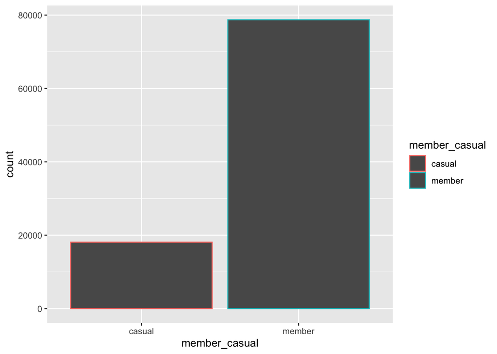

```r
ggplot(data = rsjan) +
  geom_bar(mapping = aes(x=member_casual, color=member_casual))
```

```r
library(GGally)
```